# ECN 301E Lab #4

In their famous 1928 paper, Charles Cobb and Paul Douglas estimated the production function, which is now known as the Cobb-Douglas production function (Charles Cobb and Paul Douglas, “A Theory of Production”, *American Economic Review*, 18(1), 139- 165). The data that they used for their estimation is contained in the dataset `data-exercise-cd.dta`.

Start with setting the global path:

```stata
global path "E:\Users\Buğra\Google Drive\TA\ECN 301E\Fall '18\Labs" /* change to whatever makes you happy */
```

Import the [dataset](https://drive.google.com/open?id=1OhajpBbyBqI0yjgLONyefJ5hsNl2YQNP):

```stata
use "$path\Lab 4\data-exercise-cd.dta", clear
```

## Looking at the Data

```stata
des
```

```
Contains data from E:\Users\Buğra\Google Drive\TA\ECN 301E\Fall '18\Labs\Lab 4\data-exercise-cd.dta
  obs:            24
 vars:             4                          21 Oct 2018 14:42
 size:           240
---------------------------------------------------------------------------------------------------------------------------------------------------------------------------------------------------------------------------------------------------------------
              storage   display    value
variable name   type    format     label      variable label
---------------------------------------------------------------------------------------------------------------------------------------------------------------------------------------------------------------------------------------------------------------
year            float   %9.0g                 calendar year
K               int     %8.0g                 Index of capital stock (1899=100)
L               int     %8.0g                 Index of labor input (1899=100)
GDP             int     %8.0g                 Index of output (1899=100)
---------------------------------------------------------------------------------------------------------------------------------------------------------------------------------------------------------------------------------------------------------------
Sorted by: year
```

```stata
sum
```

```
    Variable |        Obs        Mean    Std. Dev.       Min        Max
-------------+---------------------------------------------------------
        year |         24      1910.5    7.071068       1899       1922
           K |         24    234.1667    106.2666        100        431
           L |         24    145.7917    29.61636        100        200
         GDP |         24    165.9167    43.75318        100        240
```

```stata
tab year
```

```
   calendar |
       year |      Freq.     Percent        Cum.
------------+-----------------------------------
       1899 |          1        4.17        4.17
       1900 |          1        4.17        8.33
       1901 |          1        4.17       12.50
       1902 |          1        4.17       16.67
       1903 |          1        4.17       20.83
       1904 |          1        4.17       25.00
       1905 |          1        4.17       29.17
       1906 |          1        4.17       33.33
       1907 |          1        4.17       37.50
       1908 |          1        4.17       41.67
       1909 |          1        4.17       45.83
       1910 |          1        4.17       50.00
       1911 |          1        4.17       54.17
       1912 |          1        4.17       58.33
       1913 |          1        4.17       62.50
       1914 |          1        4.17       66.67
       1915 |          1        4.17       70.83
       1916 |          1        4.17       75.00
       1917 |          1        4.17       79.17
       1918 |          1        4.17       83.33
       1919 |          1        4.17       87.50
       1920 |          1        4.17       91.67
       1921 |          1        4.17       95.83
       1922 |          1        4.17      100.00
------------+-----------------------------------
      Total |         24      100.00
```

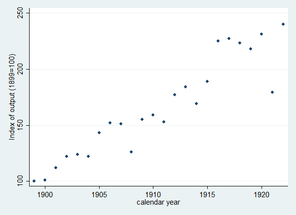

```stata
scatter GDP year /* a basic scatter graph */
```

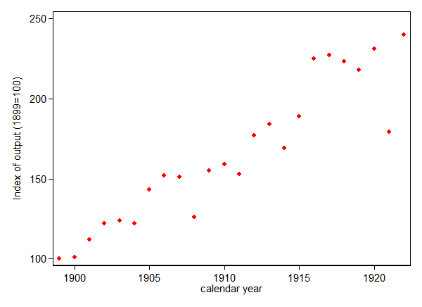

```stata
scatter GDP year, mcolor(red) ylabel(,angle(0)) scheme(s1color) /* an aesthetically pleasing scatter graph */
```

Type `help(scatter)` to learn more about scatter graph settings.

**Examine the dataset `data-exercise-cd.dta`. What is the average growth rate of GDP over the sample period?**

Summarize GDP:

```stata
tab year, sum(GDP)
```

```
            |     Summary of Index of output
   calendar |             (1899=100)
       year |        Mean   Std. Dev.       Freq.
------------+------------------------------------
       1899 |         100           0           1
       1900 |         101           0           1
       1901 |         112           0           1
       1902 |         122           0           1
       1903 |         124           0           1
       1904 |         122           0           1
       1905 |         143           0           1
       1906 |         152           0           1
       1907 |         151           0           1
       1908 |         126           0           1
       1909 |         155           0           1
       1910 |         159           0           1
       1911 |         153           0           1
       1912 |         177           0           1
       1913 |         184           0           1
       1914 |         169           0           1
       1915 |         189           0           1
       1916 |         225           0           1
       1917 |         227           0           1
       1918 |         223           0           1
       1919 |         218           0           1
       1920 |         231           0           1
       1921 |         179           0           1
       1922 |         240           0           1
------------+------------------------------------
      Total |   165.91667   43.753178          24
```

Display average growth version 1 (not compounding!).

```stata
disp ((240-100)/100)/24
```

```
.05833333
```

Average growth is $5.8\%$.

Display average growth version 2 (compounding!).

```stata
disp (240/100)^(1/24)-1
```

```
.03715135
```

Geometric mean growth is $3.7\%$.

```stata
tsset year
```

```
        time variable:  year, 1899 to 1922
                delta:  1 unit
```

This command declares the data to be a time series data and defines the variable `year` as the variable capturing time.

```stata
gen gGDP = (GDP - L.GDP)/L.GDP
```

```
(1 missing value generated)
```

After defining the data as time series we can use L. to denote the value of the variable in the previous period alternatively in this sample we can refer to the observations directly  
`gen gGDP = (GDP[_n] - GDP[_n-1])/GDP[_n-1]`

```stata
sum gGDP
```

```
    Variable |        Obs        Mean    Std. Dev.       Min        Max
-------------+---------------------------------------------------------
        gGDP |         23    .0459773    .1247373  -.2251082   .3407821
```

Average of the annual growth rate is $4.6\%$.

**The general form of the Cobb-Douglas production function is:**

$$ Y = A K^{\alpha} L^{\beta} $$

**where $Y$ is GDP, $K$ a measure of the physical capital stock and $L$ a measure of the amount of labor input. Is is possible to directly estimate this function with the linear model? How could one transform the equation so that it becomes linear?**

We can take (natural) logs on both sides:

$$ln(Y) = ln(A) + \alpha ln(K) + \beta ln(L) $$

this is linear and if we allow for some error in the approximation:

$$ ln(Y_t) = ln(A) + \alpha ln(K_t) + \beta ln(L_t) + u_t $$

gives us a regression equation linear in the parameters.

**Use the data contained in `data-exercise-cd.dta` to estimate the Cobb-Douglas production function. Are the coefficients $\alpha$ and $\beta$ statistically significant? What is the economic interpretation of these coefficients?**

```stata
gen lnY = ln(GDP)
gen lnK = ln(K)
gen lnL = ln(L)

reg lnY lnK lnL
```

```
      Source |       SS           df       MS      Number of obs   =        24
-------------+----------------------------------   F(2, 21)        =    236.12
       Model |  1.59622155         2  .798110773   Prob > F        =    0.0000
    Residual |  .070981736        21  .003380083   R-squared       =    0.9574
-------------+----------------------------------   Adj R-squared   =    0.9534
       Total |  1.66720328        23  .072487099   Root MSE        =    .05814

------------------------------------------------------------------------------
         lnY |      Coef.   Std. Err.      t    P>|t|     [95% Conf. Interval]
-------------+----------------------------------------------------------------
         lnK |   .2330537   .0635298     3.67   0.001     .1009363    .3651711
         lnL |    .807278   .1450762     5.56   0.000     .5055755    1.108981
       _cons |  -.1773099   .4342933    -0.41   0.687    -1.080472    .7258525
------------------------------------------------------------------------------
```

Interpretation & discussion:

$\alpha$ and $\beta$ are the *elasticities* of GDP to capital and labor respectively.

That is: if you increase the input by $1\%$ GDP increases by $\alpha$% or $\beta$%.

Moreover: If we assume perfect competition they are also the capital and labor share of the output! (Why? Do we believe this? What does this mean?)

Both coefficients are significantly different from zero at the $5\%$ (and $1\%$) level labor has an elasticity of $0.8$, capital of $0.23$.

So far our dependent and explanatory variables were all in levels, with both sides in level the interpretation of the estimated coefficients was in level terms, i.e. a one-unit change in the explanatory variable is associated with a  
**(estimated coefficient) $\times$ 1 unit change of the dependent variable**.

When we consider variables **in natural log terms** this changes and we can use **percentage changes** to interpret the result: the estimated coefficients are elasticities. A $1\%$ change in the explanatory varible gives us a **(estimated coefficient)%** change in the dependent variable.

**Use a F-Test to test the hypothesis that both $\alpha$ and $\beta$ are equal to zero.**

We want to test whether both $\alpha$ and $\beta$ are zero. We will use the post-estimation command `test` from exercise 3 this tests hypotheses about most recently estimated model.

```stata
test lnK lnL
```

```
 ( 1)  lnK = 0
 ( 2)  lnL = 0

       F(  2,    21) =  236.12
            Prob > F =    0.0000
```

Interpretation & discussion:

$H_0$: $\alpha = 0$ and $\beta = 0$  
$H_A$: at least one of the parameters is not equal to $0$

- the p-value is below $.05$ and $.01$ which means we can reject the $H_0$ at the $5\%$ and $1\%$ significance level
- the coefficients are jointly significant (not surprising since they are individually significant as well)

**What is the relationship between the error term in your regression and the implicit error term in (1)?**

Discussion:

We estimate

$$ ln(Y_t) = ln(A) + \alpha ln(K_t) + \beta ln(L_t) + u_t $$

exponentiating both sides gives us the original equation including an error term

$$ Y_t = A K_t^{\alpha} L_t^{\beta} e^{u_t} $$

the error has to be *multiplicative* in out initial equation. The multiplicative error does not *add some random error* to the deterministic part, but rather *scales* the deterministic part to equate the RHS with the observed LHS value.

**The Cobb-Douglas production function has constant returns to scale if** $\alpha + \beta = 1$ **. How could you estimate the production function under this restriction? Test the hypothesis that there are constant returns to scale with a F-Test.**

```stata
test lnK + lnL == 1
```

```
 ( 1)  lnK + lnL = 1

       F(  1,    21) =    0.20
            Prob > F =    0.6628
```

$H_0$: constant returns to scale  
$H_A$: no constant returns to scale

The restriction implies:

$$ln(Y_t) = ln(A) + \alpha ln(K_t) + (1-\alpha) ln(L_t) + u_t$$$$ln(Y_t) - ln(L_t) = ln(A) + \alpha (ln(K_t) - ln(L_t)) + u_t$$

```stata
gen lnY_constraint = lnY - lnL
gen lnKL_constraint = lnK - lnL

reg lnY_constraint lnKL_constraint
```

```
      Source |       SS           df       MS      Number of obs   =        24
-------------+----------------------------------   F(1, 22)        =     38.00
       Model |  .123761295         1  .123761295   Prob > F        =    0.0000
    Residual |  .071642825        22  .003256492   R-squared       =    0.6334
-------------+----------------------------------   Adj R-squared   =    0.6167
       Total |   .19540412        23  .008495831   Root MSE        =    .05707

---------------------------------------------------------------------------------
 lnY_constraint |      Coef.   Std. Err.      t    P>|t|     [95% Conf. Interval]
----------------+----------------------------------------------------------------
lnKL_constraint |   .2541344   .0412236     6.16   0.000     .1686418    .3396269
          _cons |   .0145445   .0199793     0.73   0.474      -.02689    .0559791
---------------------------------------------------------------------------------
```

Assuming constant returns to scale (i.e. if we double both inputs we double the output) we find that the elasticity of labor is $0.75$ and the elasticity of capital is $0.25$.

Our baseline model has residual (unaccounted for) sum of squares  
$.070981736$

Our new "restricted" model has residual sum of squares  
$.071642825$

Compute F statistic "by hand" using sum of squared residuals (SSR):

```stata
disp ((.071642825 - .070981736) / 1 ) /  (.070981736 / (24 - 3))
```

```
.19558368
```

Now we are confused. We wonder what the critical F values are. Is our statistic so large that it is highly unusual under the null? Or is it small?

In Google type "f statistic critical values stata". Your first hit tells you what to do to get critical values in Stata.

Display the critical value:

```stata
display invFtail(1,24-3,.05)
```

```
4.3247937
```

Display the p-value for our F-statistic (for now just plug in value by hand and rounded):

```stata
display Ftail(1,24-3,0.19)
```

```
.66736454
```

A second way of answering the question is:

```stata
constraint define 1 lnL = 1 - lnK
cnsreg lnY lnK lnL, constraint(1)
```

```
Constrained linear regression                   Number of obs     =         24
                                                Root MSE          =     0.0571

 ( 1)  lnK + lnL = 1
------------------------------------------------------------------------------
         lnY |      Coef.   Std. Err.      t    P>|t|     [95% Conf. Interval]
-------------+----------------------------------------------------------------
         lnK |   .2541344   .0412236     6.16   0.000     .1686418    .3396269
         lnL |   .7458656   .0412236    18.09   0.000     .6603731    .8313582
       _cons |   .0145445   .0199793     0.73   0.474      -.02689    .0559791
------------------------------------------------------------------------------
```

## Do-file

The `do-file` for this exercise can be found [here](https://drive.google.com/open?id=11Zv4BtA1Anc_i2W8tqRK4XK8xIiaKKAe).